# Mini Data-Analysis Deliverable 1

# Welcome to your (maybe) first-ever data analysis project!

And hopefully the first of many. Let’s get started:

1. Install the [`datateachr`](https://github.com/UBC-MDS/datateachr) package by typing the following into your **R terminal**:

```
install.packages("devtools")
devtools::install_github("UBC-MDS/datateachr")
```

2. Load the packages below.

```r
library(datateachr)
library(tidyverse)
```

3. Make a repository in the https://github.com/stat545ubc-2021 Organization. You will be working with this repository for the entire data analysis project. You can either make it public, or make it private and add the TA’s and Vincenzo as collaborators.
   - UPDATE: There is now a link that will help you make a repo. It’s [on canvas](https://canvas.ubc.ca/courses/80816/pages/mini-data-analysis-create-a-repository) (and on a Slack announcement).
4. When you go to submit, submit a URL to your repository to canvas.

# Instructions

More details regarding the instructions and points allocated to each task can be found below. Briefly,

- Each milestone is worth 30 points. The number of points allocated to each task will be annotated within each deliverable. Tasks that are more challenging will often be allocated more points.
- 10 points will be allocated to the reproducibility, cleanliness, and coherence of the analysis. While the three milestones will be submitted as independent deliverables, the analysis itself is a continuum - think of it as 3 chapters to a story. Each chapter, or in this case, portion of your analysis, should be easily followed through by someone unfamiliar with the content. [Here](https://swcarpentry.github.io/r-novice-inflammation/06-best-practices-R/) is a good resource for what constitutes “good code”. Learning good coding practices early in your career will save you hassle later on!

# Learning Objectives

By the end of this milestone, you should:

- Become familiar with your dataset of choosing
- Think of 4 questions that you would like to answer with your data
- Generate a reproducible and clear report using R Markdown

# Task 1: Choose your favorite dataset (10 points)

The `datateachr` package by Hayley Boyce and Jordan Bourak currently composed of 7 semi-tidy datasets for educational purposes. Here is a brief description of each dataset:

- *apt_buildings*: Acquired courtesy of The City of Toronto’s Open Data Portal. It currently has 3455 rows and 37 columns.
- *building_permits*: Acquired courtesy of The City of Vancouver’s Open Data Portal. It currently has 20680 rows and 14 columns.
- *cancer_sample*: Acquired courtesy of UCI Machine Learning Repository. It currently has 569 rows and 32 columns.
- *flow_sample*: Acquired courtesy of The Government of Canada’s Historical Hydrometric Database. It currently has 218 rows and 7 columns.
- *parking_meters*: Acquired courtesy of The City of Vancouver’s Open Data Portal. It currently has 10032 rows and 22 columns.
- *steam_games*: Acquired courtesy of Kaggle. It currently has 40833 rows and 21 columns.
- *vancouver_trees*: Acquired courtesy of The City of Vancouver’s Open Data Portal. It currently has 146611 rows and 20 columns.

**Things to keep in mind**

- We hope that this project will serve as practice for carrying our your own *independent* data analysis. Remember to comment your code, be explicit about what you are doing, and write notes in this markdown document when you feel that context is required. As you advance in the project, prompts and hints to do this will be diminished - it’ll be up to you!
- Before choosing a dataset, you should always keep in mind **your goal**, or in other ways, *what you wish to achieve with this data*. This mini data-analysis project focuses on *data wrangling*, *tidying*, and *visualization*. In short, it’s a way for you to get your feet wet with exploring data on your own.

And that is exactly the first thing that you will do!

1.1 Out of the 7 datasets available in the `datateachr` package, choose **4** that appeal to you based on their description. Write your choices below:

```r
head(cancer_sample)
```

```
## # A tibble: 6 x 32
##         ID diagnosis radius_mean texture_mean perimeter_mean area_mean
##      <dbl> <chr>           <dbl>        <dbl>          <dbl>     <dbl>
## 1   842302 M                18.0         10.4          123.      1001
## 2   842517 M                20.6         17.8          133.      1326
## 3 84300903 M                19.7         21.2          130       1203
## 4 84348301 M                11.4         20.4           77.6      386.
## 5 84358402 M                20.3         14.3          135.      1297
## 6   843786 M                12.4         15.7           82.6      477.
## # ... with 26 more variables: smoothness_mean <dbl>, compactness_mean <dbl>,
## #   concavity_mean <dbl>, concave_points_mean <dbl>, symmetry_mean <dbl>,
## #   fractal_dimension_mean <dbl>, radius_se <dbl>, texture_se <dbl>,
## #   perimeter_se <dbl>, area_se <dbl>, smoothness_se <dbl>,
## #   compactness_se <dbl>, concavity_se <dbl>, concave_points_se <dbl>,
## #   symmetry_se <dbl>, fractal_dimension_se <dbl>, radius_worst <dbl>,
## #   texture_worst <dbl>, perimeter_worst <dbl>, area_worst <dbl>, ...
```

```r
head(vancouver_trees)
```

```
## # A tibble: 6 x 20
##   tree_id civic_number std_street genus_name species_name cultivar_name
##     <dbl>        <dbl> <chr>      <chr>      <chr>        <chr>
## 1  149556          494 W 58TH AV  ULMUS      AMERICANA    BRANDON
## 2  149563          450 W 58TH AV  ZELKOVA    SERRATA      <NA>
## 3  149579         4994 WINDSOR ST STYRAX     JAPONICA     <NA>
## 4  149590          858 E 39TH AV  FRAXINUS   AMERICANA    AUTUMN APPLAUSE
## 5  149604         5032 WINDSOR ST ACER       CAMPESTRE    <NA>
## 6  149616          585 W 61ST AV  PYRUS      CALLERYANA   CHANTICLEER
## # ... with 14 more variables: common_name <chr>, assigned <chr>,
## #   root_barrier <chr>, plant_area <chr>, on_street_block <dbl>,
## #   on_street <chr>, neighbourhood_name <chr>, street_side_name <chr>,
## #   height_range_id <dbl>, diameter <dbl>, curb <chr>, date_planted <date>,
## #   longitude <dbl>, latitude <dbl>
```

```r
head(steam_games)
```

```
## # A tibble: 6 x 21
##      id url    types  name  desc_snippet recent_reviews all_reviews release_date
##   <dbl> <chr>  <chr>  <chr> <chr>        <chr>          <chr>       <chr>
## 1     1 https~ app    DOOM  Now include~ Very Positive~ Very Posit~ May 12, 2016
## 2     2 https~ app    PLAY~ PLAYERUNKNO~ Mixed,(6,214)~ Mixed,(836~ Dec 21, 2017
## 3     3 https~ app    BATT~ Take comman~ Mixed,(166),-~ Mostly Pos~ Apr 24, 2018
## 4     4 https~ app    DayZ  The post-so~ Mixed,(932),-~ Mixed,(167~ Dec 13, 2018
## 5     5 https~ app    EVE ~ EVE Online ~ Mixed,(287),-~ Mostly Pos~ May 6, 2003
## 6     6 https~ bundle Gran~ Grand Theft~ NaN            NaN         NaN
## # ... with 13 more variables: developer <chr>, publisher <chr>,
## #   popular_tags <chr>, game_details <chr>, languages <chr>,
## #   achievements <dbl>, genre <chr>, game_description <chr>,
## #   mature_content <chr>, minimum_requirements <chr>,
## #   recommended_requirements <chr>, original_price <dbl>, discount_price <dbl>
```

```r
head(apt_buildings)
```

```
## # A tibble: 6 x 37
##      id air_conditioning amenities   balconies barrier_free_acc~ bike_parking
##   <dbl> <chr>            <chr>       <chr>     <chr>             <chr>
## 1 10359 NONE             Outdoor re~ YES       YES               0 indoor parki~
## 2 10360 NONE             Outdoor po~ YES       NO                0 indoor parki~
## 3 10361 NONE             <NA>        YES       NO                Not Available
## 4 10362 NONE             <NA>        YES       YES               Not Available
## 5 10363 NONE             <NA>        NO        NO                12 indoor park~
## 6 10364 NONE             <NA>        NO        NO                Not Available
## # ... with 31 more variables: exterior_fire_escape <chr>, fire_alarm <chr>,
## #   garbage_chutes <chr>, heating_type <chr>, intercom <chr>,
## #   laundry_room <chr>, locker_or_storage_room <chr>, no_of_elevators <dbl>,
## #   parking_type <chr>, pets_allowed <chr>, prop_management_company_name <chr>,
## #   property_type <chr>, rsn <dbl>, separate_gas_meters <chr>,
## #   separate_hydro_meters <chr>, separate_water_meters <chr>,
## #   site_address <chr>, sprinkler_system <chr>, visitor_parking <chr>, ...
```

**Note**: We encourage you to use the ones in the `datateachr` package, but if you have a dataset that you’d really like to use, you can include it here. But, please check with a member of the teaching team to see whether the dataset is of appropriate complexity. Also, include a **brief** description of the dataset here to help the teaching team understand your data.

1: CANCER_SAMPLE  
2: VANCOUVER_TREES  
3: STEAM_GAMES  
4: APT_BUILDINGS

1.2 One way to narrowing down your selection is to *explore* the datasets. Use your knowledge of dplyr to find out at least *3* attributes about each of these datasets (an attribute is something such as number of rows, variables, class type…). The goal here is to have an idea of *what the data looks like*.

*Hint:* This is one of those times when you should think about the cleanliness of your analysis. I added a single code chunk for you, but do you want to use more than one? Would you like to write more comments outside of the code chunk?

*Exploration notes* Glimpse() will show some information regarding columns and rows of the data; whereas head() will show the first few rows of the data to give an idea of the values I could potentially work with; lastly, I will also look at the summary() of the data for a basic overview. This will be repeated for all four data sets

*exploring cancer_sample data set*

```r
glimpse(cancer_sample)
```

```
## Rows: 569
## Columns: 32
## $ ID                      <dbl> 842302, 842517, 84300903, 84348301, 84358402, ~
## $ diagnosis               <chr> "M", "M", "M", "M", "M", "M", "M", "M", "M", "~
## $ radius_mean             <dbl> 17.990, 20.570, 19.690, 11.420, 20.290, 12.450~
## $ texture_mean            <dbl> 10.38, 17.77, 21.25, 20.38, 14.34, 15.70, 19.9~
## $ perimeter_mean          <dbl> 122.80, 132.90, 130.00, 77.58, 135.10, 82.57, ~
## $ area_mean               <dbl> 1001.0, 1326.0, 1203.0, 386.1, 1297.0, 477.1, ~
## $ smoothness_mean         <dbl> 0.11840, 0.08474, 0.10960, 0.14250, 0.10030, 0~
## $ compactness_mean        <dbl> 0.27760, 0.07864, 0.15990, 0.28390, 0.13280, 0~
## $ concavity_mean          <dbl> 0.30010, 0.08690, 0.19740, 0.24140, 0.19800, 0~
## $ concave_points_mean     <dbl> 0.14710, 0.07017, 0.12790, 0.10520, 0.10430, 0~
## $ symmetry_mean           <dbl> 0.2419, 0.1812, 0.2069, 0.2597, 0.1809, 0.2087~
## $ fractal_dimension_mean  <dbl> 0.07871, 0.05667, 0.05999, 0.09744, 0.05883, 0~
## $ radius_se               <dbl> 1.0950, 0.5435, 0.7456, 0.4956, 0.7572, 0.3345~
```

[output cut: 19 more lines]

```r
head(cancer_sample)
```

```
## # A tibble: 6 x 32
##         ID diagnosis radius_mean texture_mean perimeter_mean area_mean
##      <dbl> <chr>           <dbl>        <dbl>          <dbl>     <dbl>
## 1   842302 M                18.0         10.4          123.      1001
## 2   842517 M                20.6         17.8          133.      1326
## 3 84300903 M                19.7         21.2          130       1203
## 4 84348301 M                11.4         20.4           77.6      386.
## 5 84358402 M                20.3         14.3          135.      1297
## 6   843786 M                12.4         15.7           82.6      477.
## # ... with 26 more variables: smoothness_mean <dbl>, compactness_mean <dbl>,
## #   concavity_mean <dbl>, concave_points_mean <dbl>, symmetry_mean <dbl>,
## #   fractal_dimension_mean <dbl>, radius_se <dbl>, texture_se <dbl>,
## #   perimeter_se <dbl>, area_se <dbl>, smoothness_se <dbl>,
## #   compactness_se <dbl>, concavity_se <dbl>, concave_points_se <dbl>,
## #   symmetry_se <dbl>, fractal_dimension_se <dbl>, radius_worst <dbl>,
## #   texture_worst <dbl>, perimeter_worst <dbl>, area_worst <dbl>, ...
```

```r
summary(cancer_sample)
```

```
##        ID             diagnosis          radius_mean      texture_mean
##  Min.   :     8670   Length:569         Min.   : 6.981   Min.   : 9.71
##  1st Qu.:   869218   Class :character   1st Qu.:11.700   1st Qu.:16.17
##  Median :   906024   Mode  :character   Median :13.370   Median :18.84
##  Mean   : 30371831                      Mean   :14.127   Mean   :19.29
##  3rd Qu.:  8813129                      3rd Qu.:15.780   3rd Qu.:21.80
##  Max.   :911320502                      Max.   :28.110   Max.   :39.28
##  perimeter_mean     area_mean      smoothness_mean   compactness_mean
##  Min.   : 43.79   Min.   : 143.5   Min.   :0.05263   Min.   :0.01938
##  1st Qu.: 75.17   1st Qu.: 420.3   1st Qu.:0.08637   1st Qu.:0.06492
##  Median : 86.24   Median : 551.1   Median :0.09587   Median :0.09263
##  Mean   : 91.97   Mean   : 654.9   Mean   :0.09636   Mean   :0.10434
##  3rd Qu.:104.10   3rd Qu.: 782.7   3rd Qu.:0.10530   3rd Qu.:0.13040
##  Max.   :188.50   Max.   :2501.0   Max.   :0.16340   Max.   :0.34540
##  concavity_mean    concave_points_mean symmetry_mean    fractal_dimension_mean
##  Min.   :0.00000   Min.   :0.00000     Min.   :0.1060   Min.   :0.04996
##  1st Qu.:0.02956   1st Qu.:0.02031     1st Qu.:0.1619   1st Qu.:0.05770
##  Median :0.06154   Median :0.03350     Median :0.1792   Median :0.06154
##  Mean   :0.08880   Mean   :0.04892     Mean   :0.1812   Mean   :0.06280
##  3rd Qu.:0.13070   3rd Qu.:0.07400     3rd Qu.:0.1957   3rd Qu.:0.06612
##  Max.   :0.42680   Max.   :0.20120     Max.   :0.3040   Max.   :0.09744
##    radius_se        texture_se      perimeter_se       area_se
##  Min.   :0.1115   Min.   :0.3602   Min.   : 0.757   Min.   :  6.802
##  1st Qu.:0.2324   1st Qu.:0.8339   1st Qu.: 1.606   1st Qu.: 17.850
##  Median :0.3242   Median :1.1080   Median : 2.287   Median : 24.530
##  Mean   :0.4052   Mean   :1.2169   Mean   : 2.866   Mean   : 40.337
##  3rd Qu.:0.4789   3rd Qu.:1.4740   3rd Qu.: 3.357   3rd Qu.: 45.190
##  Max.   :2.8730   Max.   :4.8850   Max.   :21.980   Max.   :542.200
##  smoothness_se      compactness_se      concavity_se     concave_points_se
##  Min.   :0.001713   Min.   :0.002252   Min.   :0.00000   Min.   :0.000000
##  1st Qu.:0.005169   1st Qu.:0.013080   1st Qu.:0.01509   1st Qu.:0.007638
##  Median :0.006380   Median :0.020450   Median :0.02589   Median :0.010930
##  Mean   :0.007041   Mean   :0.025478   Mean   :0.03189   Mean   :0.011796
##  3rd Qu.:0.008146   3rd Qu.:0.032450   3rd Qu.:0.04205   3rd Qu.:0.014710
##  Max.   :0.031130   Max.   :0.135400   Max.   :0.39600   Max.   :0.052790
##   symmetry_se       fractal_dimension_se  radius_worst   texture_worst
##  Min.   :0.007882   Min.   :0.0008948    Min.   : 7.93   Min.   :12.02
##  1st Qu.:0.015160   1st Qu.:0.0022480    1st Qu.:13.01   1st Qu.:21.08
##  Median :0.018730   Median :0.0031870    Median :14.97   Median :25.41
##  Mean   :0.020542   Mean   :0.0037949    Mean   :16.27   Mean   :25.68
##  3rd Qu.:0.023480   3rd Qu.:0.0045580    3rd Qu.:18.79   3rd Qu.:29.72
##  Max.   :0.078950   Max.   :0.0298400    Max.   :36.04   Max.   :49.54
##  perimeter_worst    area_worst     smoothness_worst  compactness_worst
##  Min.   : 50.41   Min.   : 185.2   Min.   :0.07117   Min.   :0.02729
##  1st Qu.: 84.11   1st Qu.: 515.3   1st Qu.:0.11660   1st Qu.:0.14720
##  Median : 97.66   Median : 686.5   Median :0.13130   Median :0.21190
##  Mean   :107.26   Mean   : 880.6   Mean   :0.13237   Mean   :0.25427
##  3rd Qu.:125.40   3rd Qu.:1084.0   3rd Qu.:0.14600   3rd Qu.:0.33910
##  Max.   :251.20   Max.   :4254.0   Max.   :0.22260   Max.   :1.05800
##  concavity_worst  concave_points_worst symmetry_worst   fractal_dimension_worst
##  Min.   :0.0000   Min.   :0.00000      Min.   :0.1565   Min.   :0.05504
##  1st Qu.:0.1145   1st Qu.:0.06493      1st Qu.:0.2504   1st Qu.:0.07146
##  Median :0.2267   Median :0.09993      Median :0.2822   Median :0.08004
##  Mean   :0.2722   Mean   :0.11461      Mean   :0.2901   Mean   :0.08395
##  3rd Qu.:0.3829   3rd Qu.:0.16140      3rd Qu.:0.3179   3rd Qu.:0.09208
##  Max.   :1.2520   Max.   :0.29100      Max.   :0.6638   Max.   :0.20750
```

*exploring vancouver_trees data set*

```r
glimpse(vancouver_trees)
```

```
## Rows: 146,611
## Columns: 20
## $ tree_id            <dbl> 149556, 149563, 149579, 149590, 149604, 149616, 149~
## $ civic_number       <dbl> 494, 450, 4994, 858, 5032, 585, 4909, 4925, 4969, 7~
## $ std_street         <chr> "W 58TH AV", "W 58TH AV", "WINDSOR ST", "E 39TH AV"~
## $ genus_name         <chr> "ULMUS", "ZELKOVA", "STYRAX", "FRAXINUS", "ACER", "~
## $ species_name       <chr> "AMERICANA", "SERRATA", "JAPONICA", "AMERICANA", "C~
## $ cultivar_name      <chr> "BRANDON", NA, NA, "AUTUMN APPLAUSE", NA, "CHANTICL~
## $ common_name        <chr> "BRANDON ELM", "JAPANESE ZELKOVA", "JAPANESE SNOWBE~
## $ assigned           <chr> "N", "N", "N", "Y", "N", "N", "N", "N", "N", "N", "~
## $ root_barrier       <chr> "N", "N", "N", "N", "N", "N", "N", "N", "N", "N", "~
## $ plant_area         <chr> "N", "N", "4", "4", "4", "B", "6", "6", "3", "3", "~
## $ on_street_block    <dbl> 400, 400, 4900, 800, 5000, 500, 4900, 4900, 4900, 7~
## $ on_street          <chr> "W 58TH AV", "W 58TH AV", "WINDSOR ST", "E 39TH AV"~
## $ neighbourhood_name <chr> "MARPOLE", "MARPOLE", "KENSINGTON-CEDAR COTTAGE", "~
## $ street_side_name   <chr> "EVEN", "EVEN", "EVEN", "EVEN", "EVEN", "ODD", "ODD~
## $ height_range_id    <dbl> 2, 4, 3, 4, 2, 2, 3, 3, 2, 2, 2, 5, 3, 2, 2, 2, 2, ~
## $ diameter           <dbl> 10.00, 10.00, 4.00, 18.00, 9.00, 5.00, 15.00, 14.00~
## $ curb               <chr> "N", "N", "Y", "Y", "Y", "Y", "Y", "Y", "Y", "Y", "~
## $ date_planted       <date> 1999-01-13, 1996-05-31, 1993-11-22, 1996-04-29, 19~
## $ longitude          <dbl> -123.1161, -123.1147, -123.0846, -123.0870, -123.08~
## $ latitude           <dbl> 49.21776, 49.21776, 49.23938, 49.23469, 49.23894, 4~
```

```r
head(vancouver_trees)
```

```
## # A tibble: 6 x 20
##   tree_id civic_number std_street genus_name species_name cultivar_name
##     <dbl>        <dbl> <chr>      <chr>      <chr>        <chr>
## 1  149556          494 W 58TH AV  ULMUS      AMERICANA    BRANDON
## 2  149563          450 W 58TH AV  ZELKOVA    SERRATA      <NA>
## 3  149579         4994 WINDSOR ST STYRAX     JAPONICA     <NA>
## 4  149590          858 E 39TH AV  FRAXINUS   AMERICANA    AUTUMN APPLAUSE
## 5  149604         5032 WINDSOR ST ACER       CAMPESTRE    <NA>
## 6  149616          585 W 61ST AV  PYRUS      CALLERYANA   CHANTICLEER
## # ... with 14 more variables: common_name <chr>, assigned <chr>,
## #   root_barrier <chr>, plant_area <chr>, on_street_block <dbl>,
## #   on_street <chr>, neighbourhood_name <chr>, street_side_name <chr>,
## #   height_range_id <dbl>, diameter <dbl>, curb <chr>, date_planted <date>,
## #   longitude <dbl>, latitude <dbl>
```

```r
summary(vancouver_trees)
```

```
##     tree_id        civic_number    std_street         genus_name
##  Min.   :    12   Min.   :    0   Length:146611      Length:146611
##  1st Qu.: 65464   1st Qu.: 1306   Class :character   Class :character
##  Median :134903   Median : 2604   Mode  :character   Mode  :character
##  Mean   :131892   Mean   : 2937
##  3rd Qu.:194450   3rd Qu.: 4005
##  Max.   :266203   Max.   :17888
##
##  species_name       cultivar_name      common_name          assigned
##  Length:146611      Length:146611      Length:146611      Length:146611
##  Class :character   Class :character   Class :character   Class :character
##  Mode  :character   Mode  :character   Mode  :character   Mode  :character
##
##
##
##
##  root_barrier        plant_area        on_street_block  on_street
##  Length:146611      Length:146611      Min.   :   0    Length:146611
##  Class :character   Class :character   1st Qu.:1300    Class :character
##  Mode  :character   Mode  :character   Median :2600    Mode  :character
##                                        Mean   :2909
##                                        3rd Qu.:4000
##                                        Max.   :9900
##
##  neighbourhood_name street_side_name   height_range_id     diameter
##  Length:146611      Length:146611      Min.   : 0.000   Min.   :  0.00
##  Class :character   Class :character   1st Qu.: 1.000   1st Qu.:  3.50
##  Mode  :character   Mode  :character   Median : 2.000   Median :  9.00
##                                        Mean   : 2.627   Mean   : 11.49
##                                        3rd Qu.: 4.000   3rd Qu.: 16.50
##                                        Max.   :10.000   Max.   :435.00
##
##      curb            date_planted          longitude         latitude
##  Length:146611      Min.   :1989-10-27   Min.   :-123.2   Min.   :49.20
##  Class :character   1st Qu.:1998-02-23   1st Qu.:-123.1   1st Qu.:49.23
##  Mode  :character   Median :2004-01-28   Median :-123.1   Median :49.25
##                     Mean   :2004-04-07   Mean   :-123.1   Mean   :49.25
##                     3rd Qu.:2010-03-02   3rd Qu.:-123.1   3rd Qu.:49.26
##                     Max.   :2019-07-03   Max.   :-123.0   Max.   :49.29
##                     NA's   :76548        NA's   :22771    NA's   :22771
```

*exploring steam_games data set*

```r
glimpse(steam_games)
```

```
## Rows: 40,833
## Columns: 21
## $ id                       <dbl> 1, 2, 3, 4, 5, 6, 7, 8, 9, 10, 11, 12, 13, 14~
## $ url                      <chr> "https://store.steampowered.com/app/379720/DO~
## $ types                    <chr> "app", "app", "app", "app", "app", "bundle", ~
## $ name                     <chr> "DOOM", "PLAYERUNKNOWN'S BATTLEGROUNDS", "BAT~
## $ desc_snippet             <chr> "Now includes all three premium DLC packs (Un~
## $ recent_reviews           <chr> "Very Positive,(554),- 89% of the 554 user re~
## $ all_reviews              <chr> "Very Positive,(42,550),- 92% of the 42,550 u~
## $ release_date             <chr> "May 12, 2016", "Dec 21, 2017", "Apr 24, 2018~
## $ developer                <chr> "id Software", "PUBG Corporation", "Harebrain~
## $ publisher                <chr> "Bethesda Softworks,Bethesda Softworks", "PUB~
## $ popular_tags             <chr> "FPS,Gore,Action,Demons,Shooter,First-Person,~
## $ game_details             <chr> "Single-player,Multi-player,Co-op,Steam Achie~
## $ languages                <chr> "English,French,Italian,German,Spanish - Spai~
## $ achievements             <dbl> 54, 37, 128, NA, NA, NA, 51, 55, 34, 43, 72, ~
## $ genre                    <chr> "Action", "Action,Adventure,Massively Multipl~
## $ game_description         <chr> "About This Game Developed by id software, th~
## $ mature_content           <chr> NA, "Mature Content Description  The develope~
## $ minimum_requirements     <chr> "Minimum:,OS:,Windows 7/8.1/10 (64-bit versio~
## $ recommended_requirements <chr> "Recommended:,OS:,Windows 7/8.1/10 (64-bit ve~
## $ original_price           <dbl> 19.99, 29.99, 39.99, 44.99, 0.00, NA, 59.99, ~
## $ discount_price           <dbl> 14.99, NA, NA, NA, NA, 35.18, 70.42, 17.58, N~
```

```r
head(steam_games)
```

```
## # A tibble: 6 x 21
##      id url    types  name  desc_snippet recent_reviews all_reviews release_date
##   <dbl> <chr>  <chr>  <chr> <chr>        <chr>          <chr>       <chr>
## 1     1 https~ app    DOOM  Now include~ Very Positive~ Very Posit~ May 12, 2016
## 2     2 https~ app    PLAY~ PLAYERUNKNO~ Mixed,(6,214)~ Mixed,(836~ Dec 21, 2017
## 3     3 https~ app    BATT~ Take comman~ Mixed,(166),-~ Mostly Pos~ Apr 24, 2018
## 4     4 https~ app    DayZ  The post-so~ Mixed,(932),-~ Mixed,(167~ Dec 13, 2018
## 5     5 https~ app    EVE ~ EVE Online ~ Mixed,(287),-~ Mostly Pos~ May 6, 2003
## 6     6 https~ bundle Gran~ Grand Theft~ NaN            NaN         NaN
## # ... with 13 more variables: developer <chr>, publisher <chr>,
## #   popular_tags <chr>, game_details <chr>, languages <chr>,
## #   achievements <dbl>, genre <chr>, game_description <chr>,
## #   mature_content <chr>, minimum_requirements <chr>,
## #   recommended_requirements <chr>, original_price <dbl>, discount_price <dbl>
```

```r
summary(steam_games)
```

```
##        id            url               types               name
##  Min.   :    1   Length:40833       Length:40833       Length:40833
##  1st Qu.:10209   Class :character   Class :character   Class :character
##  Median :20417   Mode  :character   Mode  :character   Mode  :character
##  Mean   :20417
##  3rd Qu.:30625
##  Max.   :40833
##
##  desc_snippet       recent_reviews     all_reviews        release_date
##  Length:40833       Length:40833       Length:40833       Length:40833
##  Class :character   Class :character   Class :character   Class :character
##  Mode  :character   Mode  :character   Mode  :character   Mode  :character
##
##
##
##
##   developer          publisher         popular_tags       game_details
##  Length:40833       Length:40833       Length:40833       Length:40833
##  Class :character   Class :character   Class :character   Class :character
##  Mode  :character   Mode  :character   Mode  :character   Mode  :character
##
##
##
##
##   languages          achievements        genre           game_description
##  Length:40833       Min.   :   1.00   Length:40833       Length:40833
##  Class :character   1st Qu.:  12.00   Class :character   Class :character
##  Mode  :character   Median :  21.00   Mode  :character   Mode  :character
##                     Mean   :  77.24
##                     3rd Qu.:  38.00
##                     Max.   :9821.00
##                     NA's   :28639
##  mature_content     minimum_requirements recommended_requirements
##  Length:40833       Length:40833         Length:40833
##  Class :character   Class :character     Class :character
##  Mode  :character   Mode  :character     Mode  :character
##
##
##
##
##  original_price     discount_price
##  Min.   :     0.0   Min.   :  0.00
##  1st Qu.:     2.0   1st Qu.:  8.78
##  Median :     5.0   Median : 19.98
##  Mean   :    53.1   Mean   : 46.82
##  3rd Qu.:    10.0   3rd Qu.: 43.92
##  Max.   :730640.0   Max.   :962.60
##  NA's   :5353       NA's   :26290
```

*exploring apt_buildings data set*

```r
glimpse(apt_buildings)
```

```
## Rows: 3,455
## Columns: 37
## $ id                               <dbl> 10359, 10360, 10361, 10362, 10363, 10~
## $ air_conditioning                 <chr> "NONE", "NONE", "NONE", "NONE", "NONE~
## $ amenities                        <chr> "Outdoor rec facilities", "Outdoor po~
## $ balconies                        <chr> "YES", "YES", "YES", "YES", "NO", "NO~
## $ barrier_free_accessibilty_entr   <chr> "YES", "NO", "NO", "YES", "NO", "NO",~
## $ bike_parking                     <chr> "0 indoor parking spots and 10 outdoo~
## $ exterior_fire_escape             <chr> "NO", "NO", "NO", "YES", "NO", NA, "N~
## $ fire_alarm                       <chr> "YES", "YES", "YES", "YES", "YES", "Y~
## $ garbage_chutes                   <chr> "YES", "YES", "NO", "NO", "NO", "NO",~
## $ heating_type                     <chr> "HOT WATER", "HOT WATER", "HOT WATER"~
## $ intercom                         <chr> "YES", "YES", "YES", "YES", "YES", "Y~
## $ laundry_room                     <chr> "YES", "YES", "YES", "YES", "YES", "Y~
## $ locker_or_storage_room           <chr> "NO", "YES", "YES", "YES", "NO", "YES~
```

[output cut: 24 more lines]

```r
head(apt_buildings)
```

```
## # A tibble: 6 x 37
##      id air_conditioning amenities   balconies barrier_free_acc~ bike_parking
##   <dbl> <chr>            <chr>       <chr>     <chr>             <chr>
## 1 10359 NONE             Outdoor re~ YES       YES               0 indoor parki~
## 2 10360 NONE             Outdoor po~ YES       NO                0 indoor parki~
## 3 10361 NONE             <NA>        YES       NO                Not Available
## 4 10362 NONE             <NA>        YES       YES               Not Available
## 5 10363 NONE             <NA>        NO        NO                12 indoor park~
## 6 10364 NONE             <NA>        NO        NO                Not Available
## # ... with 31 more variables: exterior_fire_escape <chr>, fire_alarm <chr>,
## #   garbage_chutes <chr>, heating_type <chr>, intercom <chr>,
## #   laundry_room <chr>, locker_or_storage_room <chr>, no_of_elevators <dbl>,
## #   parking_type <chr>, pets_allowed <chr>, prop_management_company_name <chr>,
## #   property_type <chr>, rsn <dbl>, separate_gas_meters <chr>,
## #   separate_hydro_meters <chr>, separate_water_meters <chr>,
## #   site_address <chr>, sprinkler_system <chr>, visitor_parking <chr>, ...
```

```r
summary(apt_buildings)
```

```
##        id        air_conditioning    amenities          balconies
##  Min.   :10359   Length:3455        Length:3455        Length:3455
##  1st Qu.:11222   Class :character   Class :character   Class :character
##  Median :12086   Mode  :character   Mode  :character   Mode  :character
##  Mean   :12086
##  3rd Qu.:12950
##  Max.   :13813
##
##  barrier_free_accessibilty_entr bike_parking       exterior_fire_escape
##  Length:3455                    Length:3455        Length:3455
##  Class :character               Class :character   Class :character
##  Mode  :character               Mode  :character   Mode  :character
##
##
##
##
##   fire_alarm        garbage_chutes     heating_type         intercom
##  Length:3455        Length:3455        Length:3455        Length:3455
##  Class :character   Class :character   Class :character   Class :character
##  Mode  :character   Mode  :character   Mode  :character   Mode  :character
##
##
##
##
##  laundry_room       locker_or_storage_room no_of_elevators  parking_type
##  Length:3455        Length:3455            Min.   : 0.000   Length:3455
##  Class :character   Class :character       1st Qu.: 0.000   Class :character
##  Mode  :character   Mode  :character       Median : 1.000   Mode  :character
##                                            Mean   : 1.208
##                                            3rd Qu.: 2.000
##                                            Max.   :32.000
##                                            NA's   :5
##  pets_allowed       prop_management_company_name property_type
##  Length:3455        Length:3455                  Length:3455
##  Class :character   Class :character             Class :character
##  Mode  :character   Mode  :character             Mode  :character
##
##
##
##
```

[output cut: 33 more lines]

```
##  Min.   :  0.000                 Length:3455          Length:3455
##  1st Qu.:  0.000                 Class :character     Class :character
##  Median :  1.000                 Mode  :character     Mode  :character
##  Mean   :  6.559
##  3rd Qu.:  5.000
##  Max.   :340.000
##  NA's   :123
##  no_barrier_free_accessible_units
##  Min.   :  0.000
##  1st Qu.:  0.000
##  Median :  0.000
##  Mean   :  9.408
##  3rd Qu.:  1.000
##  Max.   :474.000
##  NA's   :154
```

1.3 Now that you’ve explored the 4 datasets that you were initially most interested in, let’s narrow it down to 2. What lead you to choose these 2? Briefly explain your choices below, and feel free to include any code in your explanation.

*CHOICE 1* cancer_sample: I am in biomedical research, so I was initially drawn to the data. Once I looked through the data briefly, I believe it could be interesting to see how the diagnosis itself could relate to several parameters and characteristics. This in turn could be analysed and could possibly used to train a program to support diagnoses.

*CHOICE 2* vancouver_trees: I like this data set because it contains a good mixture of numerical and text variables, and because I believe it could be used to create a very detailed map/graph of distribution of trees at some point during the analysis.

1.4 Time for the final decision! Going back to the beginning, it’s important to have an *end goal* in mind. For example, if I had chosen the `titanic` dataset for my project, I might’ve wanted to explore the relationship between survival and other variables. Try to think of 1 research question that you would want to answer with each dataset. Note them down below, and make your final choice based on what seems more interesting to you!

*CHOICE 1* cancer_sample:how does texture and area influence the diagnosis of the sample, and how can we use this to build a predictive model in the future? *CHOICE 2* vancouver_trees:which city areas have the greatest concentration of planted trees?

# Important note

Read Tasks 2 and 3 *fully* before starting to complete either of them. Probably also a good point to grab a coffee to get ready for the fun part!

This project is semi-guided, but meant to be *independent*. For this reason, you will complete tasks 2 and 3 below (under the **START HERE** mark) as if you were writing your own exploratory data analysis report, and this guidance never existed! Feel free to add a brief introduction section to your project, format the document with markdown syntax as you deem appropriate, and structure the analysis as you deem appropriate. Remember, marks will be awarded for completion of the 4 tasks, but 10 points of the whole project are allocated to a reproducible and clean analysis. If you feel lost, you can find a sample data analysis [here](https://www.kaggle.com/headsortails/tidy-titarnic) to have a better idea. However, bear in mind that it is **just an example** and you will not be required to have that level of complexity in your project.

# Task 2: Exploring your dataset (15 points)

If we rewind and go back to the learning objectives, you’ll see that by the end of this deliverable, you should have formulated *4* research questions about your data that you may want to answer during your project. However, it may be handy to do some more exploration on your dataset of choice before creating these questions - by looking at the data, you may get more ideas. **Before you start this task, read all instructions carefully until you reach START HERE**.

2.1 Complete *4 out of the following 8 exercises* to dive deeper into your data. All datasets are different and therefore, not all of these tasks may make sense for your data - which is why you should only answer *4*. Use *dplyr* and *ggplot*.

2.2 For each of the 4 exercises that you complete, provide a *brief explanation* of why you chose that exercise in relation to your data (in other words, why does it make sense to do that?), and sufficient comments for a reader to understand your reasoning and code.

*I will be using the cancer data set (CHOICE 1). Some information about the data:*

- The data set comes from the Breast Cancer Wisconsin (Diagnostic) Data Set
- “Features are computed from a digitized image of a fine needle aspirate (FNA) of a breast mass. They describe characteristics of the cell nuclei present in the image”
- containing the following attributes:
1. ID number
2. Diagnosis (M = malignant, B = benign) 3-32)

Ten real-valued features are computed for each cell nucleus:

1. radius (mean of distances from center to points on the perimeter)
2. texture (standard deviation of gray-scale values)
3. perimeter
4. area
5. smoothness (local variation in radius lengths)
6. compactness (perimeter^2 / area - 1.0)
7. concavity (severity of concave portions of the contour)
8. concave points (number of concave portions of the contour)
9. symmetry
10. fractal dimension (“coastline approximation” -1)

*I will be completing the following 4 exercises*

1. Plot the distribution of a numeric variable.

I want to see how the area is distributed, and group it by diagnosis, to see what tumor sizes I can expect to see when I perform more analyses.

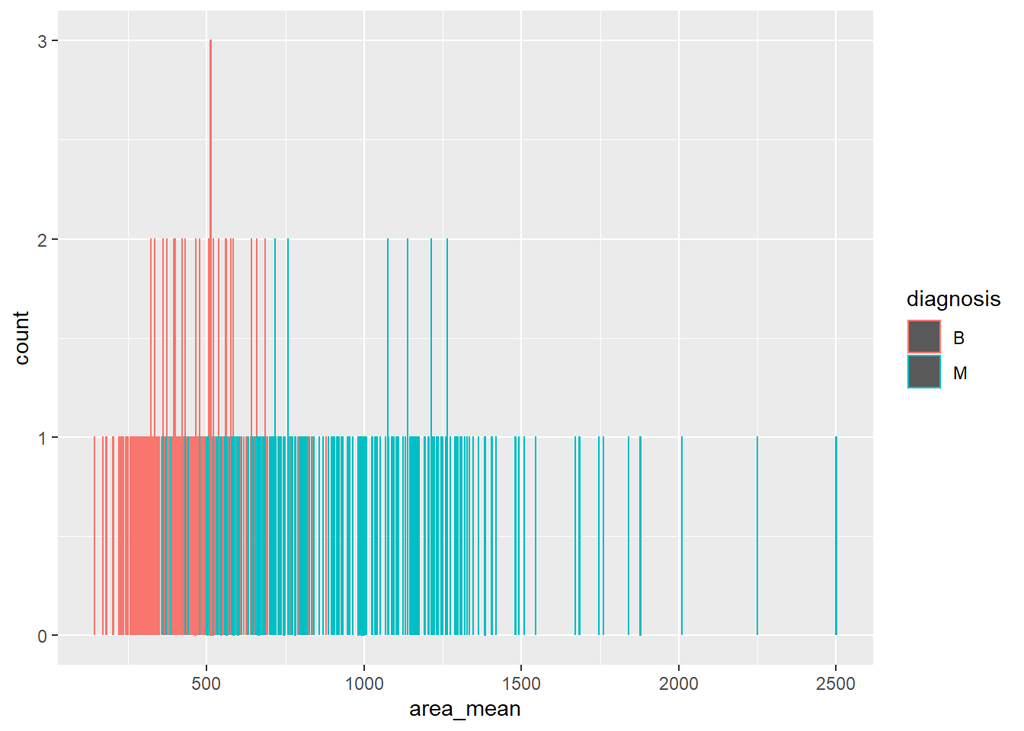

```r
sizing_plot <- ggplot(cancer_sample, aes(area_mean)) +
  geom_bar(aes(color = diagnosis))

print(sizing_plot)
```

It looks like most higher values are going to be malignant, whereas most benign tumors tend to be smaller, although there is an area of overlap. We will have to look at other values to determine how we can differentiate between benign and malignant tumors.

4. Explore the relationship between 2 variables in a plot. Seeing some trend with the area, I also want to see how the area compares with the symmetry, and if there are any trends when looking at diagnoses.

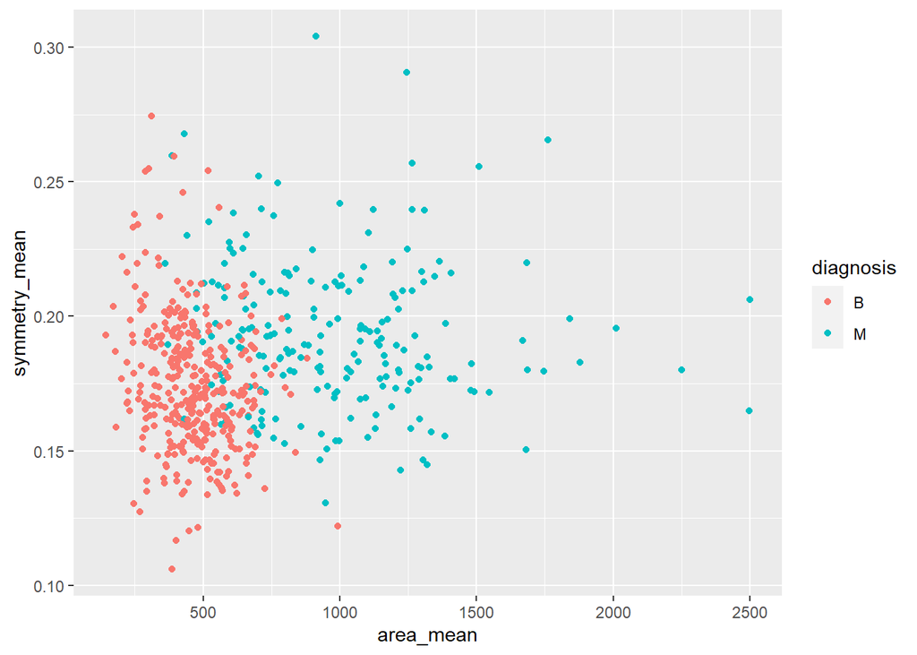

```r
area_symmetry_plot <- ggplot(cancer_sample, aes(area_mean, symmetry_mean))+
  geom_point(aes(colour = diagnosis))

print(area_symmetry_plot)
```

There seems to be a tighter knit cluster for benign tumors than malignant tumors. Will need to use other factors also.

5. Filter observations in your data according to your own criteria.

```r
cancer_area <- cancer_sample %>%
  filter(area_mean > 1000)

head(cancer_area)
```

```
## # A tibble: 6 x 32
##         ID diagnosis radius_mean texture_mean perimeter_mean area_mean
##      <dbl> <chr>           <dbl>        <dbl>          <dbl>     <dbl>
## 1   842302 M                18.0         10.4           123.      1001
## 2   842517 M                20.6         17.8           133.      1326
## 3 84300903 M                19.7         21.2           130       1203
## 4 84358402 M                20.3         14.3           135.      1297
## 5   844359 M                18.2         20.0           120.      1040
## 6   846226 M                19.2         24.8           132.      1123
## # ... with 26 more variables: smoothness_mean <dbl>, compactness_mean <dbl>,
## #   concavity_mean <dbl>, concave_points_mean <dbl>, symmetry_mean <dbl>,
## #   fractal_dimension_mean <dbl>, radius_se <dbl>, texture_se <dbl>,
## #   perimeter_se <dbl>, area_se <dbl>, smoothness_se <dbl>,
## #   compactness_se <dbl>, concavity_se <dbl>, concave_points_se <dbl>,
## #   symmetry_se <dbl>, fractal_dimension_se <dbl>, radius_worst <dbl>,
## #   texture_worst <dbl>, perimeter_worst <dbl>, area_worst <dbl>, ...
```

# Task 3: Write your research questions (5 points)

So far, you have chosen a data set and gotten familiar with it through exploring the data. Now it’s time to figure out 4 research questions that you would like to answer with your data! Write the 4 questions and any additional comments at the end of this deliverable. These questions are not necessarily set in stone - TAs will review them and give you feedback; therefore, you may choose to pursue them as they are for the rest of the project, or make modifications!

1. How is perimeter, radius and area all together related to diagnose a tumor as malignant or benign?
2. Which features are the driving factor for the diagnosis?
3. What effects does symmetry have on the radius and area of the sample?
4. Looking at the worst factors - how are these different in the diagnosis of the tumor compared to the mean values?

### Attribution

Thanks to Icíar Fernández Boyano for mostly putting this together, and Vincenzo Coia for launching.